# tutorial00-intro

Nicholas R. Record

## R Markdown

This R Markdown document walks through some basic steps to get you familiar with R and R studio.

You can click the little play arrow/triangle to run each block of code in this editor. Or, when you click the **Knit** button a document will be generated that includes both content as well as the output of any embedded R code chunks within the document.

## R as a calculator

Get warmed up by typing in some simple math equations. Feel free to edit the equation and re-run, trying some other things.

```r
5+7
```

```
## [1] 12
```

The output is what comes after the [1].

## Variables / objects

You can use letters to save values, like variables in algebra, or bits of text, or even whole collections of data, like a spreadsheet. The “<-” notation is supposed to look sort of like an arrow, pointing at the direction of the assignment.

Note that anything after the # symbol is just a note to the reader.

```r
x <- 5+7
y <- 24
x  # Show what x is
```

```
## [1] 12
```

```r
y  # Show what y is
```

```
## [1] 24
```

```r
y / x  # Show y divided by x
```

```
## [1] 2
```

Like in the first example, the output of each of the statements follows the [1].

Next we have a variable equal to a bit of text and try to divide it by a number. You’ll need to remove the # comment symbol to run the last line of code because it makes an error.

```r
z <- 'twelve'
z  # Show what z is
```

```
## [1] "twelve"
```

```r
# z / 2 # Try to divide a character string (i.e. a word) by a number
```

Below is an empty code block. Go ahead and type in some more code and play around.

```r
# Empty block of code for playing around
```

Next we’ll look at a variable that is a collection of data, sort of like a mini spreadsheet. Usually you’ll load in data from a file, but this shows how to put some data into a table from scratch.

Note that we need the ‘data.table’ library. New libraries load in new functions. If you don’t have it, you can install it using the install.packages() function. That is, you’ll need to add a line like this–

install.package(‘data.table’)

```r
library('data.table')

age <- c(55,22,13,45,10)
height <- c(200,190,175,180,120)
data <- data.table(age,height)
data
```

```
##    age height
## 1:  55    200
## 2:  22    190
## 3:  13    175
## 4:  45    180
## 5:  10    120
```

There, we just made a little data table. You can click on it in the “Environment” section of R studio to see the whole thing. You can also look at specific points in this table by using indexing.

```r
data$age[2] # The second age in the list
```

```
## [1] 22
```

```r
data$height[5] # The fifst height in the list
```

```
## [1] 120
```

## Functions

What did we do when we just loaded that library?

R has all kinds of functions built in, like min() and max() for example. Here’s how to look at the minimum and maximum of the data table we just created:

```r
min(data$age)
```

```
## [1] 10
```

```r
max(data$height)
```

```
## [1] 200
```

Each time you load in a new library, you’re loading in new functions that can do different things. You can even write your own functions. If you find yourself copying and pasting a bit of code again and again, that’s a good opportunity to try to write your own function. But that will all come later.

## Plotting

One handy function is called plot(). As you might guess, this creates a plot of data. Here we’ll plot the height versus the age from the data table we just made.

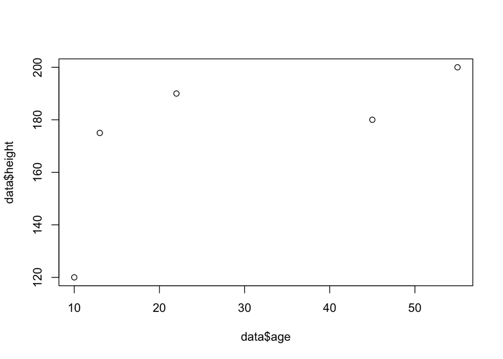

```r
plot(data$age,data$height)
```

This plot looks a little rough and sloppy. There are all kinds of ways to make the plot look better. Below is an example of a plot that’s a bit more cleaned up, including axes labeled with units (always important!).

This example uses what are called “base graphics” in R. To see more options, check out this site https://r-coder.com/plot-r/.

And if you want to dig into even fancier graphics, there are packages/libraries you can install like “ggplot2”.

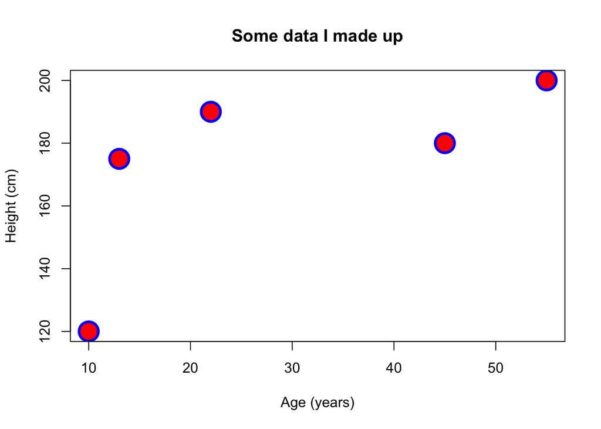

```r
plot(data$age, data$height,
     main = 'Some data I made up',
     xlab = 'Age (years)',
     ylab = 'Height (cm)',
     cex = 3,
     pch = 21,
     col = 'blue',
     bg = 'red',
     lwd = 3)
```

## Loading and Plotting Data

One last task for this tutorial– loading in some real data. We’ll use NOAA’s records of the North Atlantic Oscillation (NAO). Check it out. Instead of showing the whole data table, we’ll use the “summary” function. It gives a summary of each column in our new “nao” data table.

```r
nao <- read.csv('../data/nao.csv')
summary(nao)
```

```
##       Year         Jan.nao            Feb.nao            Mar.nao
##  Min.   :1821   Min.   :-99.9900   Min.   :-99.9900   Min.   :-99.990
##  1st Qu.:1871   1st Qu.: -0.5500   1st Qu.: -0.4150   1st Qu.: -1.163
##  Median :1922   Median :  0.7850   Median :  0.7250   Median :  0.020
##  Mean   :1922   Mean   : -0.3515   Mean   : -0.7147   Mean   : -0.860
##  3rd Qu.:1972   3rd Qu.:  1.8375   3rd Qu.:  2.0850   3rd Qu.:  1.450
##  Max.   :2022   Max.   :  4.8200   Max.   :  5.2600   Max.   :  4.050
##     Apr.nao            May.nao            Jun.nao            Jul.nao
##  Min.   :-99.9900   Min.   :-99.9900   Min.   :-99.9900   Min.   :-5.39000
##  1st Qu.: -1.0050   1st Qu.: -1.2550   1st Qu.: -1.4975   1st Qu.:-1.13000
##  Median :  0.1100   Median : -0.5050   Median : -0.3550   Median :-0.04500
##  Mean   : -0.7883   Mean   : -0.7644   Mean   : -0.9605   Mean   :-0.02352
##  3rd Qu.:  1.3875   3rd Qu.:  0.6650   3rd Qu.:  0.5375   3rd Qu.: 1.09750
##  Max.   :  6.6600   Max.   :  4.6500   Max.   :  2.9800   Max.   : 5.36000
##     Aug.nao           Sep.nao            Oct.nao           Nov.nao
##  Min.   :-3.6700   Min.   :-99.9900   Min.   :-99.990   Min.   :-99.990
##  1st Qu.:-0.5850   1st Qu.: -1.4075   1st Qu.: -1.718   1st Qu.: -1.525
##  Median : 0.3600   Median : -0.2400   Median : -0.465   Median : -0.160
##  Mean   : 0.4598   Mean   : -0.7957   Mean   : -1.980   Mean   : -1.145
##  3rd Qu.: 1.6300   3rd Qu.:  0.8150   3rd Qu.:  0.645   3rd Qu.:  1.130
##  Max.   : 4.6800   Max.   :  3.2400   Max.   :  2.790   Max.   :  4.620
##     Dec.nao              NAO
##  Min.   :-99.9900   Min.   :-99.990
##  1st Qu.: -1.0650   1st Qu.: -0.300
##  Median :  0.3650   Median :  0.050
##  Mean   : -0.6197   Mean   : -2.397
##  3rd Qu.:  1.9200   3rd Qu.:  0.455
##  Max.   :  4.2200   Max.   :  1.580
```

Again, you can click on the variable “nao” in your environment to view the whole table.

Try plotting some of the data. We’ll plot the January NAO value against Year. You’ll notice that there are some values near -100. That’s because the data file records missing values as -99.99. It makes the plot pretty much impossible to read!

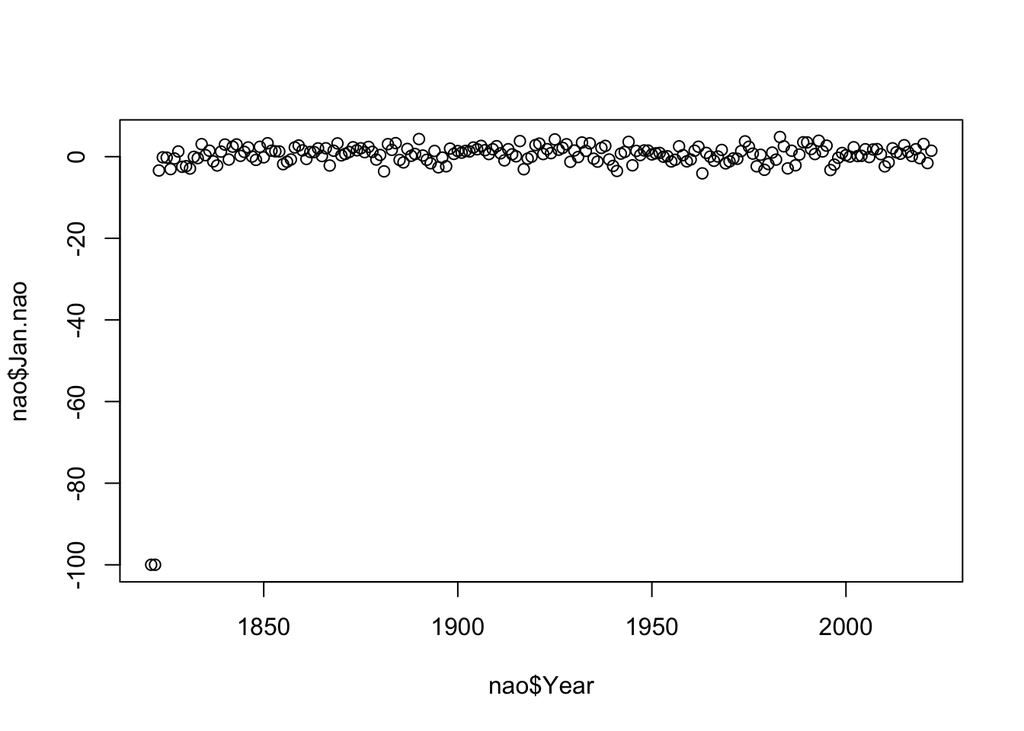

```r
plot(nao$Year,nao$Jan.nao)
```

You can replace all of those values with a statement like the one below. Anywhere the value is equal to -99.99, it replaces it with NA, which basically means no value.

Let’s do that, and make the plot a line plot.

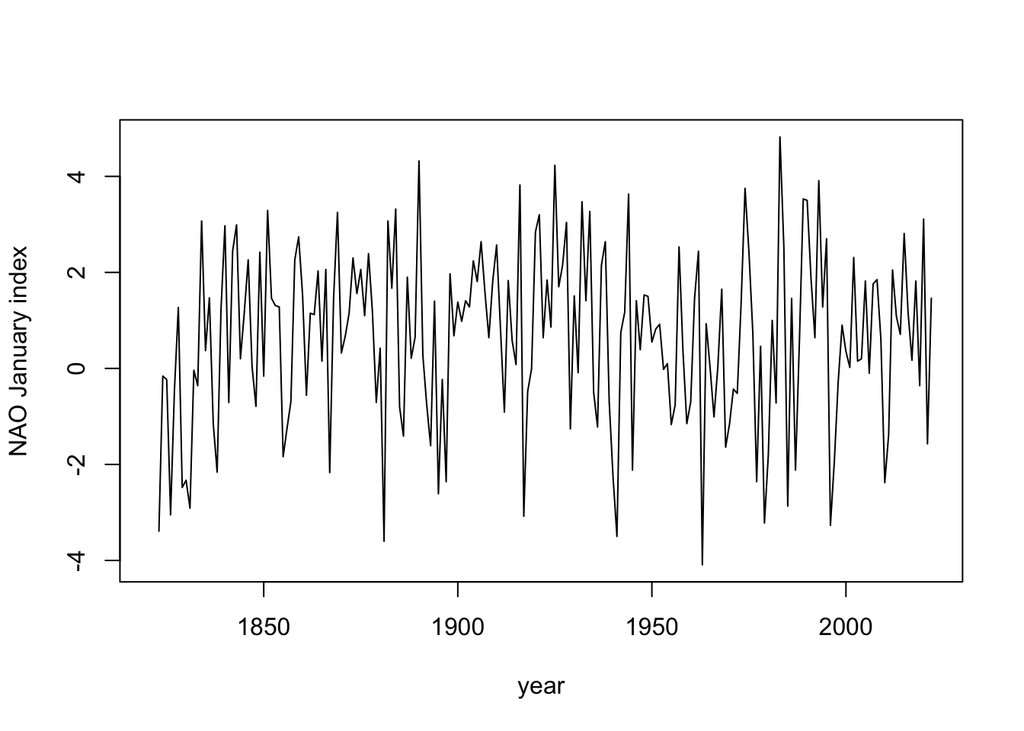

```r
nao[nao == -99.99] <- NA
plot(nao$Year,nao$Jan.nao,
     type = 'l',
     xlab = 'year',
     ylab = 'NAO January index')
```

## Assignment

There are all kinds of data sources available through repositories online. Here are some examples of ocean-related datasets:

- Global fish stock time series
  - http://www.seaaroundus.org
- Commercial fishery landings data
  - https://www.fisheries.noaa.gov/foss/f?p=215:200:4272106129122:Mail::::
  - https://www.maine.gov/dmr/commercial-fishing/landings/historical-data.html
- NOAA climate indices
  - https://psl.noaa.gov/data/climateindices/list/
- Satellite ocean data
  - https://oceancolor.gsfc.nasa.gov/
- Ocean ecosystem indicators
  - https://noaa-edab.github.io/tech-doc/

Obtain a dataset from some source. Save it as a .csv file. Load the csv file into R, and make a simple plot. Include the .csv file and R code along with your plot.